# Mediation Analysis in R

Charles Marks  
3/14/19

### The General Plan

We are going to split this up into the following sections:

- Introducing and Defining Mediation Analysis
- The Baron & Kenny Four Steps Methods
- Assessing for Significance (The Sobel Test & Boostrapping)
- Some Other (More Modern) Approaches to Mediation
- Implementing Mediation Analysis in R

### What is Mediation?

The most basic causal analysis we have is in the form of “does our IV impact our DV?”

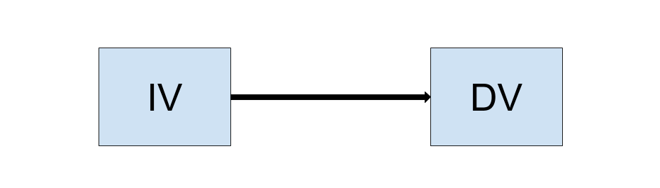

But, it's possible that even if we find that our IV significantly predicts our DV that there is a third variable (a mediator) which acts as the “underlying mechnaism” of this relationship.

### What is Mediation?

If such a variable exists, we can imagine a model in which our IV impacts our MV and then, in turn, our mediator variable (MV) may affect our DV.

Here is the path diagram of the indirect effect of our IV on our DV as mediated through our MV.

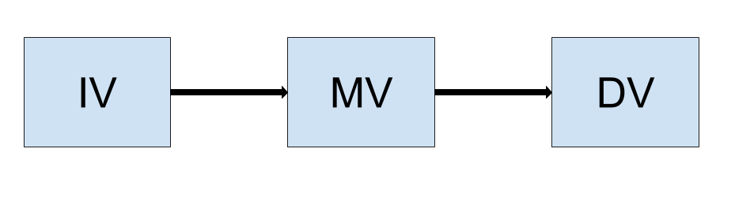

### The Full Mediation Model

Finally, when we define a full mediation model we will include both of the paths described before: the direct path from our IV to our DV; and, the indirect path from our IV, through our MV, to our DV.

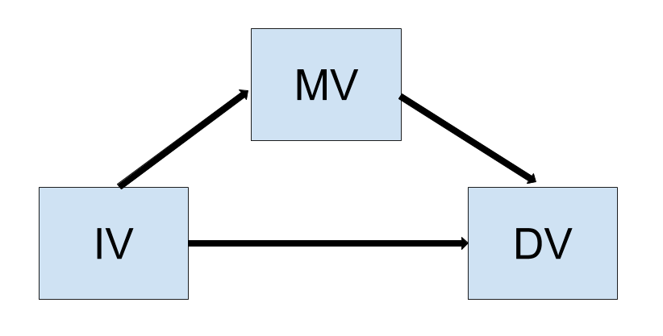

## What are some examples of this type of relationship?

### Where Does Mediation Analysis Actually Come In?

Well, typically (but not always), we start with a causal pathway between our IV and our DV. In mediation steps, we will refer to the point estimate for this relationship as **c** (also referred to as the **total effect**).

## The Path Diagram For That Simple Model

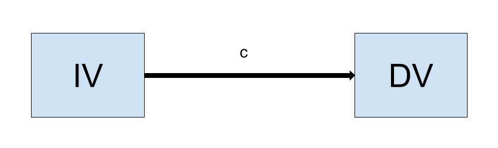

### Assessing an Underlying Mechanism

So mediation comes in when we hypothesize that this relationship, c, is actually made up of two components: the indirect effect of the IV through our MV (a) to our DV (b); the direct effect of the IV on the DV that remains (c').

### The Results of Mediation

Based on our path diagram the results that we care about are the Indirect Effect (the mediated pathway) and the Direct Effect.

## The Indirect Effect: a*b

Where a is the effect of IV on MV and b is the effect of MV on DV.

## The Direct Effect: c'

Where c' is the effect of the IV on DV as not mediated through the MV.

### No vs Partial vs Full Mediation

Say that *c* (the relationship of IV and DV in our simple model) is significant and we want to test if MV mediates the relationship between IV and DV.

**No Mediation** occurs when *c'* remains significant and *a***b* is not significant. In other words there is no significant indirect effect.

**Partial Mediation** occurs when both *c'* and *a***b* are significant. In this case the MV mediates some of the relationship between IV and DV, but there remains a different pathway that explains some of the relationship between IV and DV.

**Full Mediation** occurs when *a***b* is significant but *c'* is not. This indicates that the entire relationship between IV and DV is due to the mediating effect of MV.

### Some Discussion Questions

### What are some examples of each type (partial & full) of mediation?

### Which, in our line of work, do you think would most commonly occur?

### So, How Do We Actually Assess Mediation

We are going to go through the most commonly utilized method :

- The Baron and Kenny Method (1986)

After, we will implement them in R with some sample data so that we can see how we can apply these methods in our own research.

### First, Before Defining A Method to Use

It is important to note that the simple mediation model we have described thus far is a causal model.

## The first assumption that must be defended are the validity of the causal relationships in our model.

There will be many cases where it isn't 100% clear that there is a causal chain from our IV to our MV to our DV. **Being able to justify and defend your model's structure is a necessary first step to conducting mediation analysis**

### Baron & Kenny (1986): The Four Steps

**Step 1:** Show that the IV is causally related with the outcome. This corresponds to calculating the total effect **c**. If **c** is significant, this tells us that there is a relationship which can be mediated.

**Step 2:** Show that the IV variable is causally related with the MV. This is the calculation of **a** in our indirect effect.

**Step 3:** Show that the MV is causally related with the DV, while controlling for the effect of the IV. This is the calculation of **b** in our indirect effect.

**After the first three steps** we should have established if mediation exists. If **a**, **b** and **c** are all significant, then mediation exists and now the question is **“partial or full?”**

**Step 4:** Show the direct effect, **c'**, of IV on DV with MV controlled for. (Note this is done simultaneously as Step 3 in the same model). If we have partial mediation, then **c'** will remain significant. For full mediation, then **c'** will lose it's significance.

### Assessing Mediation

Typically though when we refer to the effect of mediation we are talking about the indirect effect **ab**. While each of these steps has allowed us to determine the existence of mediation and the type (full vs partial) we still need to assess the statistical significance of the mediated indirect effect **ab**

### Testing for Significance with the Sobel Test

The Sobel Test allows us to test for significance as long as we have the values **a**, **b** and their standard errors **\( s_a \)** and **\( s_b \)** (which we should have computed in Steps 1-4). The Sobel Test results in a z-score that can be tested against corresponding p-value thresholds:

\( z = \frac{ab}{\sqrt{b^2s_a^2 + a^2s_b^2}} \)

The Sobel Test is very conservative though and typically now is only utilized if you do not have access to the raw data. It lacks power (very conservative) and thus typically only works well with large datasets. As well, the Sobel Test assumes the independence of **a** and **b**, which can be established when we use multiple regression, but we cannot assume if we utilize logisitic regression, SEM, or other techniques.

### A More Modern Approach: Bootstrapping

Bootstrapping is a method popularized by Bradley Efron in 1979. While it is a very simple technique, it is computationally intensive and has, thus, become accessible thanks to computers.

Basics of bootstrapping are that we have a value (in the case of mediation the value is **ab**) and we want to generate a confidence interval. We will conduct \( N \) iterations of bootstrapping to determine our CI.

One iteration of bootstrapping involves taking our dataset and pulling a random sampling with replacement of the same size and then computing the desired metric we are creating a confidence interval for. **Random Sompling with Replacement** means we can take the same sample multiple times.

## Bootstrap Example

Say we had a set of values:

\( V = {4,4,5,5,7,7,7,7,9,10} \)

The mean value of this set is 6.5, but we want to know the confidence interval for this mean. So, say we run 10 bootstrap samples, we may get something like…

\[ \begin{align} & {4,4,4,4,7,7,7,7,9,9} \\ & {4,5,5,5,7,7,7,9,10,10} \\ & {4,4,4,4,4,5,7,7,9,10} \\ & {4,4,5,5,5,7,7,7,10,10} \\ & {4,4,4,4,5,7,7,7,7,7} \\ & {4,5,5,7,7,7,9,9,10,10} \\ & {4,4,4,5,7,7,7,7,9,10} \\ & {4,4,5,5,5,5,7,10,10,10} \\ & {4,4,4,5,5,7,7,7,9,9} \\ & {4,5,5,5,5,7,9,9,10,10} \end{align} \]

This gives us a set of means by which we can compute our CI:

\( {6.2, 6.9, 5.8, 6.4, 5.6, 7.3, 6.4, 6.5, 6.1, 6.9} \)

We want to find the difference between each of these and our sample mean (6.5):

\( {-0.3,0.4,-0.7,-0.1,-0.9,0.8,-0.1,0.0,-0.4,0.4} \)

Then we will sort them from smallest to largest

\( {-0.9,-0.7,-0.4,-0.3,-0.1,-0.1,0.0,0.4,0.4,0.8} \)

Now we have our distribution of means and we can choose our values for our confidence interval. Since we have only have ten bootstrap runs we don't have a lot of data, but we can get an 80% confidence interval by identifying the 10th and 90th percentile of our bootstrapped set, which would be the average of the first two and last two elements of our set, respectively.

\[ \begin{align} LL &: \frac{-0.9 + (-0.7)}{2} = -0.8 \\ UL &: \frac{0.4 + 0.8}{2} = 0.6 \\ CI &: [6.5 - 0.8, 6.5 + 0.6] = [5.7,7.1] \end{align} \]

### Bootstrapping for Mediation

While this method is very simple, the computation time is high. Bootstrapping is based on the law of large numbers, which simply states that the more times we run an experiment, the closer to the actual value we will get.

So, in order to generate a bootstrapped CI for our mediated effect **ab**, we can run, say, 1000 bootstrapped models in which we generate random samples with replacement and compute **ab**. At the end of this process we will have 1000 bootstrapped values for **ab** and we can then compute a confidence interval based on this distribution.

### Assumptions of the Baron Kenny Method

The Baron and Kenny Method is typically based on the following assumptions:

- Multiple Regression (or SEM with no latent variables) is used for all analyses (note: our MV and DV are continuous)
- The same observations are used across all analyses
- The same covariates are included across all analyses

As well, when these assumptions are met, we find this simple relation between the full effect, indirect effect, and direct effect:

\( c = c' + ab \)

That being said, the Baron and Kenny steps remain an excellent starting place regardless of if these assumptions can be met. These steps can be used to validate a mediation hypothesis, but, if the assumptions cannot be met, there are more modern methods for assessing mediated effects.

As well, it should be noted that the Baron and Kenny steps can confirm your mediation hypothesis, but that there are situations that can arise in which the Baron and Kenny steps will not identify mediation (ie you might find that the relation of X on M is not significant), but if you can defend your hypothesized mediation it is still worthwhile to run a test of mediation.

### Implementing The Baron & Kenny Method in R

Regardless of whether or not you actually utilize the Baron and Kenny method to assess the significance of your indirect effect, using the Baron and Kenny steps are generally a good approach for beginning any mediation analysis, as it allows you to validate the existence of mediation.

So, first we are going to need some data. We are going to use some sample data. This set has 100 observations with three continuous variables: X, M, Y.

```r
url <- 'http://static.lib.virginia.edu/statlab/materials/data/mediationData.csv'
df <- read.csv(url)
head(df)
```

```
  X M Y
1 6 5 6
2 7 5 5
3 7 7 4
4 8 4 8
5 4 3 5
6 4 4 7
```

### Step 1: X --> Y

First, we will calculate **c**, the total effect of X on Y.

```r
model.step_one <- lm(Y ~ X, data = df)
summary(model.step_one)
```

```
Call:
lm(formula = Y ~ X, data = df)

Residuals:
    Min      1Q  Median      3Q     Max
-5.0262 -1.2340 -0.3282  1.5583  5.1622

Coefficients:
            Estimate Std. Error t value Pr(>|t|)
(Intercept)   2.8572     0.6932   4.122 7.88e-05 ***
X             0.3961     0.1112   3.564 0.000567 ***
---
Signif. codes:  0 '***' 0.001 '**' 0.01 '*' 0.05 '.' 0.1 ' ' 1

Residual standard error: 1.929 on 98 degrees of freedom
Multiple R-squared:  0.1147,    Adjusted R-squared:  0.1057
F-statistic:  12.7 on 1 and 98 DF,  p-value: 0.0005671
```

We can see that **c = 0.3961** and that **p < 0.001**

### Step 2: X --> M

Next, we will calculate **a**, the effect of X on M.

```r
model.step_two <- lm(M ~ X, data = df)
summary(model.step_two)
```

```
Call:
lm(formula = M ~ X, data = df)

Residuals:
    Min      1Q  Median      3Q     Max
-4.3046 -0.8656  0.1344  1.1344  4.6954

Coefficients:
            Estimate Std. Error t value Pr(>|t|)
(Intercept)  1.49952    0.58920   2.545   0.0125 *
X            0.56102    0.09448   5.938 4.39e-08 ***
---
Signif. codes:  0 '***' 0.001 '**' 0.01 '*' 0.05 '.' 0.1 ' ' 1

Residual standard error: 1.639 on 98 degrees of freedom
Multiple R-squared:  0.2646,    Adjusted R-squared:  0.2571
F-statistic: 35.26 on 1 and 98 DF,  p-value: 4.391e-08
```

We can see that **a = 0.56102** and that **p < 0.001**

### Steps 3 & 4: M + X --> Y

Finally, we will calculate **b** and **c'**

```r
model.steps_three_four <- lm(Y ~ X + M, data = df)
summary(model.steps_three_four)
```

```
Call:
lm(formula = Y ~ X + M, data = df)

Residuals:
    Min      1Q  Median      3Q     Max
-3.7631 -1.2393  0.0308  1.0832  4.0055

Coefficients:
            Estimate Std. Error t value Pr(>|t|)
(Intercept)   1.9043     0.6055   3.145   0.0022 **
X             0.0396     0.1096   0.361   0.7187
M             0.6355     0.1005   6.321 7.92e-09 ***
---
Signif. codes:  0 '***' 0.001 '**' 0.01 '*' 0.05 '.' 0.1 ' ' 1

Residual standard error: 1.631 on 97 degrees of freedom
Multiple R-squared:  0.373, Adjusted R-squared:  0.3601
F-statistic: 28.85 on 2 and 97 DF,  p-value: 1.471e-10
```

We can see that **b = 0.6355** and that **p < 0.001** & that **c' = 0.0396** and that **p = 0.7187**

### Full Mediation

Okay, so the results we have thus far are:

- The full effect **c = 0.3961** (significant)
- The indirect effect **ab = 0.56102 x 0.6355 = 0.3565** (significant)
- The direct effect **c' = 0.0396** (not significant)

Because **c'** is not significant, this indicates we are talking about **full mediation**.

Note, that since we meet the Baron and Kenny assumptions, we can actually double check the formula \( c = c' + ab \) and it turns out that it holds as \( 0.3961 = 0.0396 + 0.3565 \)

## Next, We Need To Test For Significance of the Mediated Effect

### Using the Sobel Method (By Hand)

For starters, let's apply the Sobel Test. We need \( s_a \) and \( s_b \).

If we go back to **Step 2**, we can see that \( s_a = 0.095 \) and going back to **Step 3**, we see that \( s_b = 0.1005 \).

\[ \begin{align} z =& \frac{ab}{\sqrt{b^2s_a^2 + a^2s_b^2}} \\ =& \frac{0.3565}{\sqrt{0.6355^2*0.095^2 + 0.56102^2*0.1005^2}} \\ ~=& \frac{0.3565}{\sqrt{0.00364 + 0.00318}} \\ ~=& \frac{0.3565}{0.08258} \\ ~=& 4.317 \end{align} \]

Given that 1.96 is our z-score significance threshold, we see here that mediation is significant based on the conservative Sobel Test!

### Using the Sobel Test (in R)

```r
library(multilevel)
multilevel::sobel(df$X, df$M, df$Y)
```

```
$`Mod1: Y~X`
             Estimate Std. Error  t value     Pr(>|t|)
(Intercept) 2.8572046  0.6932130 4.121684 7.875771e-05
pred        0.3961261  0.1111598 3.563574 5.671128e-04

$`Mod2: Y~X+M`
              Estimate Std. Error  t value     Pr(>|t|)
(Intercept) 1.90426882  0.6054585 3.145168 2.203831e-03
pred        0.03960392  0.1096484 0.361190 7.187429e-01
med         0.63549459  0.1005339 6.321194 7.922642e-09

$`Mod3: M~X`
             Estimate Std. Error  t value     Pr(>|t|)
(Intercept) 1.4995183 0.58919773 2.545017 1.248749e-02
pred        0.5610153 0.09448048 5.937897 4.391362e-08

$Indirect.Effect
[1] 0.3565222

$SE
[1] 0.08237781

$z.value
[1] 4.327891

$N
[1] 100
```

### How About Bootstrapping Tho

So, if the Sobel test finds significant mediation, that is probably sufficient. But the Sobel test is not really the standard anymore, so we should also apply bootstrapping.

This can be done easily by using the **mediation** package in R. We also want to bring back to objects from previous slides **model.step_two** and **model.steps_three_four**

```r
library(mediation)
results <- mediation::mediate(model.step_two,
                   model.steps_three_four,
                   treat='X',
                   mediator='M',
                   boot.ci.type = "bca",
                   boot=TRUE,
                   sims=500)
```

### Bootstrapping Results

```r
summary(results)
```

```
Causal Mediation Analysis

Nonparametric Bootstrap Confidence Intervals with the BCa Method

               Estimate 95% CI Lower 95% CI Upper p-value
ACME             0.3565       0.2236         0.55  <2e-16 ***
ADE              0.0396      -0.1913         0.29    0.82
Total Effect     0.3961       0.1614         0.65  <2e-16 ***
Prop. Mediated   0.9000       0.5611         2.25  <2e-16 ***
---
Signif. codes:  0 '***' 0.001 '**' 0.01 '*' 0.05 '.' 0.1 ' ' 1

Sample Size Used: 100


Simulations: 500
```

### Other R Methods: SEM with lavaan

As well, since mediation analysis is a form of SEM, we could use an SEM package such as lavaan. Here would be how we could conduct this model in lavaan.

```r
library(lavaan)
model <- ' # direct effect
             Y ~ c*X
           # mediator
             M ~ a*X
             Y ~ b*M
           # indirect effect (a*b)
             ab := a*b
           # total effect
             total := c + (a*b)
         '
fit <- sem(model, data = df)
```

### lavaan Results

```r
summary(fit)
```

```
lavaan 0.6-3 ended normally after 14 iterations

  Optimization method                           NLMINB
  Number of free parameters                          5

  Number of observations                           100

  Estimator                                         ML
  Model Fit Test Statistic                       0.000
  Degrees of freedom                                 0
  Minimum Function Value               0.0000000000000

Parameter Estimates:

  Information                                 Expected
  Information saturated (h1) model          Structured
  Standard Errors                             Standard

Regressions:
                   Estimate  Std.Err  z-value  P(>|z|)
  Y ~
    X          (c)    0.040    0.108    0.367    0.714
  M ~
    X          (a)    0.561    0.094    5.998    0.000
  Y ~
    M          (b)    0.635    0.099    6.418    0.000

Variances:
                   Estimate  Std.Err  z-value  P(>|z|)
   .Y                 2.581    0.365    7.071    0.000
   .M                 2.633    0.372    7.071    0.000

Defined Parameters:
                   Estimate  Std.Err  z-value  P(>|z|)
    ab                0.357    0.081    4.382    0.000
    total             0.396    0.110    3.600    0.000
```

### What About Categorical Data

So, here is the thing though. The assumptions for these methods no longer hold when we have categorical data in our MV and/or our DV. The Baron and Kenny method can be used to determine if mediation exists, but underlying assumptions being broken make it not accuracte to use the same methods to determine mediation effect or test for significance.

So, first let's produce some categorical data by converty our MV **M** and our DV **Y** into categorical versions of themselves **M_cat** and **Y_cat**. Here we utilize **tidyverse** library

```r
library(tidyverse)

df <-
  df %>%
  mutate(., M_cat = ifelse(M > 5, 1, 0)) %>%
  mutate(., Y_cat = ifelse(Y > 5, 1, 0))
```

### Natural Effects Models with medflex package

```r
library(medflex)

## In medflex, the order of variables in regression matters
## Y ~ X + M + covariates
impFit <- glm(Y_cat ~ X + factor(M_cat), family = binomial("logit"), data = df)

expData <- neImpute(impFit)

neMod1 <- neModel(Y_cat~ X0 + X1, family = binomial("logit"), expData = expData, se = "robust")

summary(neMod1)
```

```
Natural effect model
with robust standard errors based on the sandwich estimator
---
Exposure: X
Mediator(s): M_cat
---
Parameter estimates:
            Estimate Std. Error z value Pr(>|z|)
(Intercept) -1.71916    0.87383  -1.967   0.0491 *
X0           0.06982    0.15013   0.465   0.6419
X1           0.16143    0.07144   2.260   0.0238 *
---
Signif. codes:  0 '***' 0.001 '**' 0.01 '*' 0.05 '.' 0.1 ' ' 1
```

```r
effdecomp <- neEffdecomp(neMod1)
summary(effdecomp)
```

```
Effect decomposition on the scale of the linear predictor
with standard errors based on the sandwich estimator
---
with x* = 0, x = 1
---
                        Estimate Std. Error z value Pr(>|z|)
natural direct effect    0.06982    0.15013   0.465   0.6419
natural indirect effect  0.16143    0.07144   2.260   0.0238 *
total effect             0.23125    0.13522   1.710   0.0872 .
---
Signif. codes:  0 '***' 0.001 '**' 0.01 '*' 0.05 '.' 0.1 ' ' 1
(Univariate p-values reported)
```

### Plotting Effect Sizes

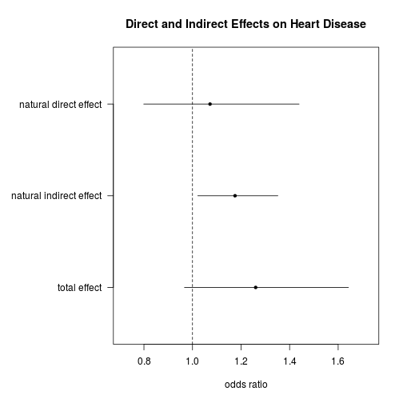

```r
plot(neMod1, xlab = "odds ratio", transf = exp, main = "Direct and Indirect Effects on Heart Disease")
```

### Citations

http://davidakenny.net/cm/mediate.htm#SE

http://quantpsy.org/sobel/sobel.htm

https://data.library.virginia.edu/introduction-to-mediation-analysis/

http://lavaan.ugent.be/tutorial/mediation.html

https://ocw.mit.edu/courses/mathematics/18-05-introduction-to-probability-and-statistics-spring-2014/readings/MIT18_05S14_Reading24.pdf

https://cran.r-project.org/web/packages/medflex/vignettes/medflex.pdf